# barycentre_example

```python
import numpy as np
import matplotlib.pyplot as plt
from scipy.stats import norm, gaussian_kde

np.random.seed(0)
```

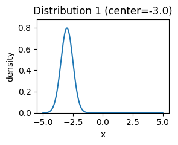

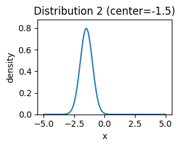

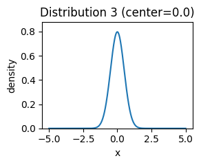

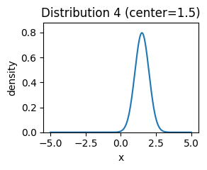

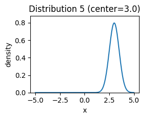

```python
x = np.linspace(-5, 5, 1000)
u = np.linspace(1e-6, 1-1e-6, 2000)

centers = [-3.0, -1.5, 0.0, 1.5, 3.0]
sigma = 0.5

densities = []
for i, c in enumerate(centers, start=1):
    pdf = norm.pdf(x, loc=c, scale=sigma)
    densities.append(pdf)
    plt.figure(figsize=(3,2.5))
    plt.plot(x, pdf)
    plt.ylim(0, np.max(pdf)*1.1)
    plt.title(f"Distribution {i} (center={c})")
    plt.xlabel("x")
    plt.ylabel("density")
    plt.tight_layout()
```

How do we "summarise" these with one typical distribution? Can we take their average as follows: $\frac{1}{5}\sum_{j=1}^{5} \hat P_j$

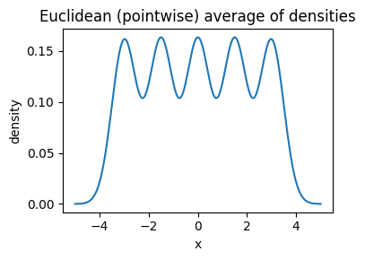

```python
# Euclidean (pointwise) average of densities
densities = np.vstack(densities)
euclid_avg = densities.mean(axis=0)


plt.figure(figsize=(4,3))
plt.plot(x, euclid_avg)
plt.title("Euclidean (pointwise) average of densities")
plt.xlabel("x")
plt.ylabel("density")
plt.tight_layout()
```

But the result doesn't look like any of the $P_j$'s :(

Instead we take Wasserstein barycentre which is the distribution $\hat P$ that will minimize: $$\sum_{j=1}^{5} W(\hat P, \hat P_j)$$

In this case (1D), it can be obtained by averaging the order statistics as follows:

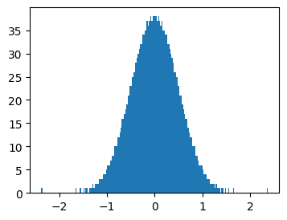

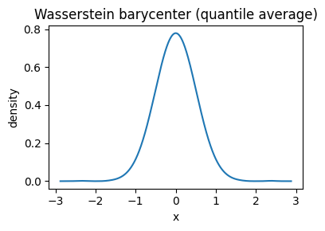

```python
quantiles = np.vstack([norm.ppf(u, loc=c, scale=sigma) for c in centers])
quantile_avg = quantiles.mean(axis=0)

plt.figure(figsize=(4,3))
plt.hist(quantile_avg, bins=200)
plt.show()

# instead if plotting the histogram, I will do the kde
kde_bary = gaussian_kde(quantile_avg)
x_bary = np.linspace(quantile_avg.min()-0.5, quantile_avg.max()+0.5, 1000)
density_bary = kde_bary(x_bary)

plt.figure(figsize=(4,3))
plt.plot(x_bary, density_bary)
plt.title("Wasserstein barycenter (quantile average)")
plt.xlabel("x")
plt.ylabel("density")
plt.tight_layout()
plt.show()
```

In the case of our project!

But I am asked to calculate the Barycentres for the Wassertein distance that we calculate for each bin $j$ (where $j \in \{1, \ldots, N\}$). But Barycentre above is for the empirical probability distribution. So I decided to try as follows instead of taking the difference between quantile functions: we can assume each bin as a dataset and calculate their empirical distribution function and hence the barycentres and then calculate the Wasserstein distance between the Barycenter of $F_n$ and Barycenter of $G_n$.

Since, $\alpha_{j} - \alpha_{j-1} = \alpha_{j+1} - \alpha_{j}$ for each $j \in \{2,3, \ldots, N\}$. So, the number of data points in each bin will also be equal.

As you told today, we take the $n$ as number of replications for each quantile $q_{\alpha_j}$ for each $j \in \{ 1, \ldots, N \}$. And then calculate their Barycentres of the quantiles.

```python
np.arange(1, 10001)
```

```
array([    1,     2,     3, ...,  9998,  9999, 10000], shape=(10000,))
```

```python
def find_nearest_quantile(data, q):
  return np.sort(np.array(data))[(np.ceil(np.array(q) * (len(data) - 1))).astype(int)]

levels = [0, 0.97, 0.98, 0.99, 1]
rv = norm.rvs(0, 1, size = 17823)
print(find_nearest_quantile(rv, levels))
print(np.quantile(rv, levels))
```

```
[-4.65995297  1.87726787  2.04853919  2.33221815  3.83179016]
[-4.65995297  1.87633684  2.0477326   2.33214548  3.83179016]
```

```python
np.histogram(rv, np.quantile(rv, levels))
```

```
(array([17288,   178,   178,   179]),
 array([-4.65995297,  1.87633684,  2.0477326 ,  2.33214548,  3.83179016]))
```

```python
np.histogram(rv, find_nearest_quantile(rv, levels))
```

```
(array([17288,   178,   178,   179]),
 array([-4.65995297,  1.87726787,  2.04853919,  2.33221815,  3.83179016]))
```